# Práctica Final en Data Driven Security (Master Cybersecuridad ed.16)

## 3.4 Enriquecimiento del **‘Dataset Muestra’**:

Con el objeto de dotar de mayor utilidad a un equipo de SOC o responsable de la cyberdefensa que recibiera las alertas automáticamente generadas por un sistema entrenado equivalente al usado en este documento, se estudia como podría mejorarse y aportar mayor Valor Añadido a la información resultante.  
A nivel de ejemplo, se podría mejorar el Dataset ya una vez entrenado el modelo, añadiendo la correspondencia de la variable **‘Attack’** con las tácticas del estándar de Mitre ATT&CK y poblar el Dataset con las variables relacionadas con su ID y el ID CWE de la debilidad expuesta, añadiendo más valor al receptor de la información o alerta.

Nota: la clasificación ha sido obtenida de fuentes de búsqueda como *Google y ChatGPT 3*, en algunos tipos no se ha podido identificar claramente etiquetándolos como **‘NotFound’**, estos casos podrían intentarse acabar de identificar usando el ejemplo visto en clase con Node4J, o con bibliotecas mas especializadas. *(se emplazaría la continuación y mejora del estudio para futuras ampliaciones de la práctica)*

```r
#### 1. carga limpio el Dataset
data_r <- read.csv("Book2.csv",header=T)
#data_r <- data

#### 2. me quedo solo con las variables numéricas en nuevo data_r
#numeric_cols <- sapply(data_r, is.numeric)
#data_r <- data_r[, numeric_cols == TRUE]
# elimino variables con Varianza zero y nzv, #eliminará la variable NumOutboundCmds
#variance <- nearZeroVar(data_r, saveMetrics = T)
#data_r <- data_r[, !(variance$zeroVar | variance$nzv)]
# Se añade la variable numerica SrcBytes ya que detectado mejora la predicción
#data_r$SrcBytes <- data$SrcBytes

#### 3. columna con alta correlación entre ellas, se pueden eliminar
#columns_to_remove <- c("DstHostSameSrvRate", "DstHostSrvRerrorRate", "DstHostRerrorRate", "RerrorRate", "DstHostSrvSerrorRate", "DstHostSerrorRate", "SrvSerrorRate")
#data_r <- data_r[, setdiff(names(data_r), columns_to_remove)]

#### 4. Se añade la variable numerica SrcBytes ya que detectado mejora la predicción
#data_r$SrcBytes <- data$SrcBytes
data_r$Attack <- as.factor(data_r$Attack)

#### 5. Definir las tácticas de ATT&CK y las variables relacionadas con su ID según estándard MITRE y CWE
tacticas_attck <- list(
  "Reconnaissance" = list(c("nmap.", "satan.", "mscan.", "snmpgetattack.", "named.", "ipsweep.", "xsnoop", "xclock.", "saint.","snmpguess.","portsweep"), "T0497", "CWE-200"),
  "Delivery" = list(c("smurf.", "neptune.", "teardrop."), "T1496", "CWE-693"),
  "Exploitation" = list(c("buffer_overflow.", "rootkit.", "loadmodule."), "T1203", "CWE-119"),
  "Privilege Escalation" = list(c("ftp_write.", "multihop.", "phf."), "T1068", "CWE-732"),
  "Command and Control" = list(c("back.", "land.", "imap."), "T1071", "CWE-1002"),
  "Lateral Movement" = list(c("guess_passwd.", "warezmaster.", "warezclient."), "T1070", "CWE-611"),
  "Exfiltration" = list(c("ftp_write.", "imap.", "spy."), "T1048", "CWE-359"),
  "Persistence" = list(c("rootkit.", "perl.", "loadmodule."), "T1547", "CWE-798"),
  "Defense Evasion" = list(c("ftp_write.", "nmap", "phf."), "T1222", "CWE-200"),
  "Denial of Service" = list(c("smurf.", "neptune.", "teardrop.", "apache2.","pod."), "T1498", "CWE-400"),
  "Normal" = list(c("normal."),"none","none"),
  "NotFound" = list(c("httptunnel.","processtable.","mailbomb.","sqlattack.","worm.","udpstorm.","xterm.","ps.","sendmail.","xlock."),"notfound","notfound")
)

# Función para clasificar la táctica de ATT&CK según las variables del dataset y añadir los IDs correspondientes
clasificar_tactica_attck <- function(registro) {
  for (tactica in names(tacticas_attck)) {
    variables <- tacticas_attck[[tactica]][[1]]
    id_attck <- tacticas_attck[[tactica]][[2]]
    id_cwe <- tacticas_attck[[tactica]][[3]]
    #if (any(registro %in% variables)) {
    if (any(grepl(paste(variables, collapse = "|"), registro))) {
      return(list(Tactica = tactica, ATTCK= id_attck, CWE = id_cwe))
    }
  }
  return(list(Tactica = "Unknown", ATTCK= "Unknown", CWE = "Unknown"))
}

# Aplicar la clasificación a cada registro del dataset y añadir los IDs correspondientes
resultados <- t(sapply(as.character(data_r$Attack), clasificar_tactica_attck))
colnames(resultados) <- c("Tactica", "ID_Tactic", "ID_CWE")

# Unir los resultados al dataset original
data_r <- cbind(data_r, as.data.frame(resultados))
data_r$Tactica <- as.character(data_r$Tactica)
data_r$ID_Tactic <- as.character(data_r$ID_Tactic)
data_r$ID_CWE <- as.character(data_r$ID_CWE)
data_r$Attack <- as.factor(data_r$Attack)

# Mostrar los valores de Attack que no han podido ser clasificados
unclassified_attacks <- data_r$Attack[data_r$Tactica == "Unknown"]

if (length(unclassified_attacks) > 0) {
  cat("Valores de Attack no clasificados:",length(unclassified_attacks),"\n")

  # Crear una tabla de valores no clasificados y contar el total de casos por cada valor
  unclassified_table <- table(unclassified_attacks)
  # Filtrar la tabla para incluir solo los valores con más de 1 caso no clasificado
  unclassified_table_filtered <- unclassified_table[unclassified_table > 0]

  # Ordenar la tabla por Attack
  unclassified_table <- unclassified_table[order(names(unclassified_table))]

  # Mostrar la tabla ordenada y el total de casos por cada valor
  #print(unclassified_table)
} else {
  cat("Todos los valores de Attack han sido clasificados correctamente.")
}
```

```
## Todos los valores de Attack han sido clasificados correctamente.
```

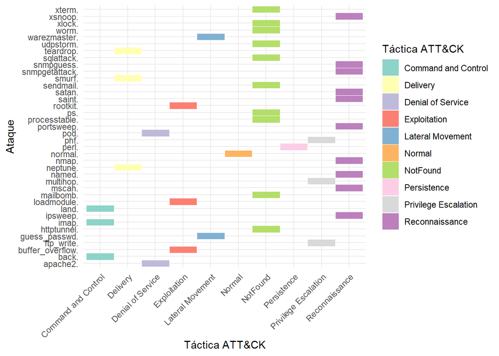

```r
# Gráfico de las partes y relaciones del dataset final
ggplot(data_r, aes(x = Tactica, y = Attack, fill = Tactica)) +
  geom_tile(color = "white") +
  labs(x = "Táctica ATT&CK", y = "Ataque", fill = "Táctica ATT&CK") +
  theme_minimal() +
  theme(axis.text.x = element_text(angle = 45, hjust = 1, vjust = 1)) +
  guides(fill = guide_legend(title = "Táctica ATT&CK")) +
  scale_fill_brewer(palette = "Set3")
```

```r
# Crear la tabla con los resultados de la clasificación y agrupar por Táctica
tabla_relacion <- data_r %>%
  group_by(Tactica) %>%
  summarise(ID_Tactic = unique(ID_Tactic),
            ID_CWE = unique(ID_CWE))

# Mostrar la tabla
kable(tabla_relacion, caption = "Relación de Táctica con IDs y CWE") %>%
    kable_styling(bootstrap_options = c("striped", "condensed"), full_width = F)
```

Relación de Táctica con IDs y CWE

| Tactica | ID_Tactic | ID_CWE |
| --- | --- | --- |
| Command and Control | T1071 | CWE-1002 |
| Delivery | T1496 | CWE-693 |
| Denial of Service | T1498 | CWE-400 |
| Exploitation | T1203 | CWE-119 |
| Lateral Movement | T1070 | CWE-611 |
| Normal | none | none |
| NotFound | notfound | notfound |
| Persistence | T1547 | CWE-798 |
| Privilege Escalation | T1068 | CWE-732 |
| Reconnaissance | T0497 | CWE-200 |

#### Testeo de la eficacia de las nuevas variables.

*se dispone del código pero no se evalua por no aportar mucha información relevante*

```r
rf_trees_fin <- rf_trees #200
part_fin <- 0.5
set.seed(123)

data_r$Tactica <- as.factor(data_r$Tactica)

# Prepara la división entre training y testing
inTrain_fin <- createDataPartition(y=data_r$Tactica, p=part_fin, list=FALSE)
training_fin <- data_r[inTrain_fin,]
testing_fin <- data_r[-inTrain_fin,]
prop.table(table(training_fin$Tactica))
prop.table(table(testing_fin$Tactica))

# Entrenar el modelo de Random Forest
control <- rfeControl(functions=rfFuncs, method="cv", number=10)

start_time <- Sys.time()
rf_fin_model <- randomForest(Tactica ~ .,
                          data = training_fin,
                          mtry = 5,
                          importance = TRUE,
                          rfeControl=control,
                          ntree = rf_trees_fin)
end_time <- Sys.time()
elapsed_time_fin <- round((end_time - start_time), 2)
rf_fin_pred <- predict(rf_fin_model, testing_fin)

cm_fin <- confusionMatrix(rf_fin_pred, testing_fin$Tactica)

#predictors(rf_fin_model)
plot(rf_fin_model)
heatmap(cm_fin$table)

rf_fin_accuracy <- round(cm_fin$overall[1], 4)*100
rf_fin_kappa <- round(cm_fin$overall[2], 4)*100
resultado_final <- data.frame( Accuracy= as.numeric(rf_fin_accuracy),
                               Kappa= as.numeric(rf_fin_kappa),
                               Tiempo= as.numeric(elapsed_time_fin))

print(resultado_final)

# Crear una nueva columna "match" en la tabla valid
valid <- testing_fin %>%
  mutate(Attack = as.character(Tactica),
         pred = as.character(rf_fin_pred),
         match = Attack == pred)

# Calcular el número total de registros por variable Attack
total_per_attack <- table(valid$Tactica)

# Calcular el número de aciertos por variable Attack
aciertos_per_attack <- tapply(valid$match, valid$Tactica, function(x) sum(x))

# Calcular el número de fallos por variable Attack
fallos_per_attack <- total_per_attack - aciertos_per_attack

# Calcular el Accuracy por variable Attack
accuracy_per_attack <- round((aciertos_per_attack / total_per_attack *100), 2)

# Crear la tabla tabla_fin con fallos, aciertos y Accuracy por variable Attack
tabla_fin <- data.frame(Attack = names(total_per_attack),
                        Aciertos = as.integer(aciertos_per_attack),
                        Fallos = as.integer(fallos_per_attack),
                        Accuracy = as.numeric(accuracy_per_attack))

# Ordenar la tabla_fin por Accuracy y Total Aciertos
tabla_fin <- tabla_fin %>%
  arrange(desc(Accuracy), desc(Aciertos))

# Mostrar la tabla tabla_fin actualizada
kable(tabla_fin, caption = "Resultado por tipo de Attack") %>%
    kable_styling(bootstrap_options = c("striped", "condensed"), full_width = F)
```

# 4 Appendix: Muestra todo el código fuente usado para este informe

```r
# Opciones de configuración de knitr
options(knitr.kable.NA = '')
options(knitr.table.format = "html")
knitr::opts_chunk$set(echo = FALSE, fig.align = 'center')

# Cargar paquetes necesarios
library(readr)
library(caret)        #modelos ML
library(randomForest) #RandomForest
library(nnet)         #Neuronal
library(e1071)        #Naive Bayes
library(dplyr)
library(ggplot2)      #gráficos
library(doParallel)   #paralelizacion
library(corrplot)
library(class)
library(data.table)
library(knitr)
library(kableExtra)
library(foreach)      #paralelizacion
library(grid)
library(DataExplorer)

#Constantes utilizadas en el programa
rf_trees <- 200    #número máximo de arboles para RandomForest Final
limite <- 30       #número mínimo de muestras para considerar el mantener una variable como autónoma
mypackages <- c("randomForest", "nnet", "readr", "caret", "e1071","dplyr","ggplot2", "doParallel","data.table", "kableExtra","corplot","class", "knitr", "tidyr", "grid")

# Crear un data.table con los paquetes
pa<-data.table(mypackages)

# Dividir el data.table en tres partes
colnames(pa)<-c("")

pa <- split(pa, rep(1:4, length.out = nrow(pa)))

kable(pa, caption = " Paquetes a Instalar:",align = c('c'),label = NA) %>%
  kable_styling(bootstrap_options = c("striped", "bordered"),full_width = FALSE)
data_full <- read_csv("Book1.csv",
                  col_types = cols(SrcBytes = col_integer(),
                                   DstBytes = col_integer(), Land = col_integer(),
                                   WrongFragment = col_integer(), Urgent = col_number(),
                                   Hot = col_number(), NumFailedLogin = col_integer()))
data <- read.csv("Book2.csv", header=T)
# Visualizar las primeras filas del Dataset Global
head(data_full)

# Visualizar las primeras filas del Dataset Muestra
head(data)
# Resumen del conjunto de datos de muestra
summary(data)

# Tipos de datos de las columnas del conjunto de datos de muestra
str(data)
dim(data)
# Obtener los tipos de datos de las columnas del dataset
tipos_datos <- sapply(data, class)
# Crear una tabla con los tipos de datos
tabla_tipos_datos <- data.frame(Columna = names(data), Tipo = tipos_datos)
# Imprimir la tabla resumen usando la función kable()
kable(tabla_tipos_datos, caption = "tipos de Variables") %>%
    kable_styling(bootstrap_options = c("striped"), full_width = F)

DataExplorer::plot_str(data)
# Contar el número de variables cualitativas, cuantitativas y factor
num_qualitative <- sum(sapply(data, is.character))
num_quantitative <- sum(sapply(data, is.numeric))
num_factor <- sum(sapply(data, is.factor))

# Crear una tabla resumen
summary_table <- data.frame(Tipo = c("Cualitativa", "Cuantitativa", "Factor"),
                            Numero = c(num_qualitative, num_quantitative, num_factor))

# Imprimir la tabla resumen usando la función knitr::kable()
kable(summary_table, caption = "Clasificación por tipos de Variables") %>%
    kable_styling(bootstrap_options = c("striped"), full_width = F)
# Obtener solo las variables cualitativas y los valores de estas
qualitative_vars <- select_if(data, is.character)
distinct_values <- lapply(qualitative_vars, unique)

# Crear una tabla resumen
summary_table2 <- data.frame(Variable = character(), Valores = character(), Categorias = integer(), stringsAsFactors = FALSE)

# Llenar la tabla resumen con los valores diferentes y el número de categorías de cada variable cualitativa
llista <- ""
for (i in 1:length(distinct_values)) {
  variable <- names(distinct_values[i])
  values <- paste(distinct_values[[i]], collapse = ", ")
  num_categories <- length(distinct_values[[i]])
  llista<- as.character(paste(llista,variable,","))
  summary_table2 <- rbind(summary_table2, data.frame(Variable = variable, Categorias = num_categories, Valores = values))
}
### Ordenar la tabla resumen por nombre de variable
summary_table2 <- summary_table2 %>% arrange(Variable)
# Imprimir la tabla resumen
kable(summary_table2, caption = "Clasificación por Variables cualitativa") %>%
    kable_styling(bootstrap_options = c("striped", "condensed"))
# Crear un gráfico explicativo por cada variable cualitativa
num_variables <- nrow(summary_table2)
num_rows <- 2  # Número de filas en la matriz de gráficos
num_cols <- ceiling(num_variables / num_rows)  # Número de columnas en la matriz de gráficos

# Establecer la disposición de los gráficos
layout(matrix(1:num_variables, nrow = num_rows, ncol = num_cols))

for (i in 1:num_variables) {
  variable <- summary_table2$Variable[i]
  plot_data <- table(data[[variable]])
  plot <- barplot(plot_data, main = paste("Muestras de ", variable),
                  xlab = "Valor Cualitativo", ylab = "Número de Muestras",
                  col = "skyblue", border = "white")
  print(plot)
}

# Restaurar la configuración del dispositivo gráfico
layout(1)
# Calcular el número de muestras duplicadas o iguales en el Dataset
duplicates <- data %>%
  group_by_all() %>%
  filter(n() > 1) %>%
  summarise(Num_Duplicates = n()) %>%
  arrange(desc(Num_Duplicates))
# Imprimir la tabla ordenada
cat("Número de muestras duplicadas en Dataset:", nrow(duplicates), "\n")
# Eliminar las muestras duplicadas y conservar solo una muestra de ellas
kdd_data_unique <- distinct(data, .keep_all = TRUE)
# Calcular el número de muestras duplicadas eliminadas
duplicates <- nrow(data) - nrow(kdd_data_unique)
# Imprimir el número de muestras duplicadas eliminadas
cat("Número de muestras duplicadas eliminadas:", duplicates, "\n")
rm(kdd_data_unique) #eliminamos dataset temporal
# Constantes: valor extremo de la diferencia de porcetage permitido XX% y cantidad mínima de muestras
difer_n <- 3
cant_min <- 1000
# Eliminar las muestras duplicadas y conservar solo una muestra de ellas
kdd_data_full_unique <- distinct(data_full, .keep_all = TRUE)
# Calcular el número de muestras duplicadas eliminadas
duplicates <- nrow(data_full) - nrow(kdd_data_full_unique)
data_full <- kdd_data_full_unique
rm(kdd_data_full_unique) #eliminamos el dataset temporal
# Imprimir el número de muestras duplicadas eliminadas
cat("Número de muestras duplicadas eliminadas en Dataset Full:", duplicates, "\n")
```

```r
# Calcular la frecuencia y porcentaje de casos por valor de Attack
attack_counts_full <- data_full[data_full$Attack != "normal.", ] %>%
  count(Attack) %>%
  mutate(Percentage_Full = round(n/sum(n) * 100, 2)) %>%
  arrange(desc(Percentage_Full))

attack_counts <- data[data$Attack != "normal.", ] %>%
  count(Attack) %>%
  mutate(Percentage = round(n/sum(n) * 100, 2)) %>%
  arrange(desc(Percentage))

# Crear una tabla combinada con los totales y porcentajes
attack_table <- merge(attack_counts_full, attack_counts, by = "Attack", suffixes = c("_Full", "_Muestra"))
attack_table <- attack_table[order(attack_table$n_Full, decreasing = TRUE),]

# Calcular la diferencia entre Diponible_Full y Disponible_Muestra
attack_table$Disponibles <- attack_table$n_Full-attack_table$n_Muestra

# Filtrar los casos con diferencia mayor al XX%
filtered_attack_table_n <- attack_table[attack_table$Disponibles > 0, ]

# Imprimir la tabla comparativa
kable(attack_table, caption = "Comparativa número de attaques por cada Dataset") %>%
    kable_styling(bootstrap_options = c("striped", "condensed"), full_width = F)

# Imprimir la tabla de casos con diferencia mayor al XX%
cat("Número de muestras disponibles diferentes en el Dataset Full:", nrow(filtered_attack_table_n), "\n")

# Crear un gráfico de barras comparativo
ggplot(attack_table, aes(x = Attack)) +
  geom_bar(aes(y = n_Full, fill = "Data_Full"), stat = "identity", just = 0) +
  geom_bar(aes(y = n_Muestra, fill = "Data"), stat = "identity", just = 1) +
  labs(title = "Número de casos por valor de Attack", x = "Attack", y = "Muestras") +
  scale_fill_manual(values = c("blue", "red"), guide = guide_legend(title = "Dataset")) +
  ggtitle("Diferencia de Muestras en Data_Full vs Data") +
  theme(axis.text.x = element_text(angle = 45, hjust = 1))
rm(data_full) #eliminamos data_full, ya no es útil
# Crear un gráfico de barras del porcentaje de casos por valor de Attack sin agrupar
ggplot(attack_counts, aes(x = reorder(Attack, -Percentage), y = Percentage)) +
  geom_bar(stat = "identity", fill = "blue") +
  labs(title = "Porcentaje de casos por valor de Attack (original)",
       x = "Attack",
       y = "Porcentaje de casos") +
  theme(axis.text.x = element_text(angle = 45, hjust = 1))

# Reemplazar valores inferiores a XX por "other" en el dataset data
data$Attack <- ifelse(data$Attack %in% attack_table$Attack[attack_table$n_Muestra < limite], "other", data$Attack)

# Filtrar los casos que no tienen el valor "normal."
data_filtered <- data %>% filter(Attack != "normal.")

# Contar la frecuencia de los valores en la columna "Attack"
frecuencia_attack <- sort(table(data_filtered$Attack), decreasing = TRUE)

# Calcular el porcentaje de casos por valor de Attack
attack_counts <- data_filtered %>%
  count(Attack) %>%
  mutate(Percentage = round(n/sum(n) * 100, 2)) %>%
  arrange(desc(Percentage))

# Crea una tabla ordenada con los totales
attack_table_final <- data.frame(
  Attack = names(frecuencia_attack),
  Total = as.numeric(frecuencia_attack),
  Porcentaje = as.numeric(attack_counts$Percentage)
)
attack_table_final <- attack_table_final[order(attack_table_final$Total, decreasing = TRUE), ]

# Crear un gráfico de barras del porcentaje de casos por valor de Attack una vez agrupado
ggplot(attack_counts, aes(x = reorder(Attack, -Percentage), y = Percentage)) +
  geom_bar(stat = "identity", fill = "blue") +
  labs(title = "Porcentaje de casos por valor de Attack (agrupado)",
       x = "Attack",
       y = "Porcentaje de casos") +
  theme(axis.text.x = element_text(angle = 45, hjust = 1))
# Imprimir la tabla comparativa
kable(attack_table_final, caption = "Comparativa número de attaques del nuevo Dataset Muestra") %>%
    kable_styling(bootstrap_options = c("striped", "condensed"), full_width = F)
# Enunciado de la práctica
data1_original <- data[,c("SrcBytes", "DstBytes", "Land", "WrongFragment", "Urgent", "SameSrvRate", "LoggedIn",  "DstHostSameSrvRate", "DstHostSrvCount","Flag","Attack" )]
data1_original$Attack <- as.factor(data1_original$Attack)
# PDF de soporte
data1_pdf <- data[,c("SrcBytes", "DstBytes", "DstHostSameSrvRate", "Count", "DstHostDiffSrvRate","Attack" )]
data1_pdf$Attack <- as.factor(data1_pdf$Attack)
# Criterio teórico de los expertos en Networking
data1_teorico <- data[,c("SrcBytes", "DstBytes", "Duration", "ProtocolType", "Service", "Flag", "Attack" )]
data1_teorico$Attack <- as.factor(data1_teorico$Attack)
# 1. Criterio de la Varianza nula o cerca del cero, columnas que se eliminan:
# "SrcBytes", "DstBytes", "Count", "DstHostSameSrvRate", "DstHostDiffSrvRate", "DstHostSrvDiffHostRate", "LoggedIn","SrvCount",
# "SerrorRate", "SrvSerrorRate", "RerrorRate", "SrvRerrorRate", "DiffSrvRate","SrvDiffHostRate", "DstHostSrvCount",
# "DstHostSameSrcPortRate", "DstHostSerrorRate", "DstHostSrvSerrorRate", "DstHostRerrorRate", "DstHostSrvRerrorRate", "NumOutboundCmds"

# me quedo solo con las variables numéricas en nuevo data1 para calcular varianzas
numeric_cols <- sapply(data, is.numeric)
data1 <- data[, numeric_cols == TRUE]
# elimino variables con Varianza zero "NumOutboundCmds" y nzv
variance <- nearZeroVar(data1, saveMetrics = T)
data1 <- data1[, !(variance$zeroVar | variance$nzv)]
# Filtrar los valores de zeroVar y nzv
variance_filtered <- variance[variance$zeroVar | variance$nzv, ]

# Imprimir la tabla resumen
kable(variance_filtered, caption = "Variables a eliminar por su baja Varianza") %>%
    kable_styling(bootstrap_options = c("striped", "condensed"), full_width = F)

# Buscamos variables correladas para eliminarlas
correlation <- cor(data1)
highlyCorrelated <- findCorrelation(correlation, verbose=F, names=T)  #selecciona a partir del 0.9 de indice de correlación

# Convertir highlyCorrelated en una única fila
highlyCorrelated_row <- paste("Correlación:", paste(highlyCorrelated, collapse = ", "))

corrplot(correlation, method="circle", title="Variables con alta Correlación", na.label= '.')

# Eliminamos filas
data1 <- data1[, setdiff(names(data1), highlyCorrelated)]
```

```r
# Añadir la variable factor "Attack" al dataset filtrado
data1$Attack <- as.factor(data$Attack)
divide <- 0.1  # 10%, toma mínima de muestras para acelerar el cálculo

set.seed(123)

# Crear partición de entrenamiento y prueba para cada Dataset
datasets <- list(
#  Estadistico = data1,
  Enunciado = data1_original,
  Ejemplo_pdf = data1_pdf,
  Teorico_net = data1_teorico,
  Estadistico = data1
)

particion <- lapply(datasets, function(data) {
  inTrain <- createDataPartition(y = data$Attack, p = divide, list = FALSE)
  list(training = data[inTrain,], testing = data[-inTrain,])
})

# Función para ajustar un modelo de random forest y obtener las predicciones
ajustar_rf <- function(data) {
  start_time <- Sys.time()
  model <- randomForest(Attack ~ ., data = data$training, ntree = rf_trees, na.action = na.fail)
  end_time <- Sys.time()
  elapsed_time <- round((end_time - start_time), 2)
  pred <- predict(model, data$testing)
  cm <- confusionMatrix(pred, data$testing$Attack)
  accuracy <- round(cm$overall[1], 4) * 100
  kappa <- round(cm$overall[2], 4) * 100
  list(model = model, pred = pred, accuracy = accuracy, kappa = kappa, cm = cm, tiempo = elapsed_time)
}

# Ajustar modelos y obtener resultados para cada dataset
resultados <- lapply(particion, ajustar_rf)

# Crear tabla de resultados
tabla_resultados <- data.frame(
  Variable = names(resultados),
  Accuracy = sapply(resultados, function(res) res$accuracy),
  Kappa = sapply(resultados, function(res) res$kappa),
  Tiempo = sapply(resultados, function(res) res$tiempo)
)
# Imprimir la tabla de resultados
kable(tabla_resultados, caption = "Comparativa por juego de predictores") %>%
  kable_styling(bootstrap_options = "striped", full_width = FALSE)
# Función para generar el gráfico y mapa de calor para cada modelo
generar_grafico <- function(result, cm, caption) {
  plot(result$model, main= caption)
  heatmap(cm$table)
  title(caption)
}

# Generar gráficos y mapas de calor para cada modelo
lapply(seq_along(resultados), function(i) generar_grafico(resultados[[i]], resultados[[i]]$cm, tabla_resultados$Variable[i]))
# Eliminar datasets y objetos temporales
rm(datasets, particion, resultados)
divide <- 0.1  # 10%, toma mínima de muestras para acelerar el cálculo

set.seed(123)
inTrain <- createDataPartition(y=data1$Attack, p=divide, list=FALSE)
training <- data1[inTrain,]
testing <- data1[-inTrain,]

# Función para calcular precisión y tiempo de ejecución
calculate_accuracy_time <- function(model, training, testing, method_name) {
  end_time <- Sys.time()
  elapsed_time <- round((end_time - start_time), 2)
  pred <- predict(model, testing)
  cm_model <- confusionMatrix(pred, testing$Attack)
  cm_accuracy <- round(cm_model$overall[1], 4)*100
  cm_kappa <- round(cm_model$overall[2], 4)*100
  heatmap(cm_model$table)
  title(method_name)
  list(Modelo = method_name, Accuracy = cm_accuracy, Kappa = cm_kappa, Tiempo = elapsed_time)
}
results <- list()

# Random Forest
start_time <- Sys.time()
rf_model <- randomForest(Attack ~ ., data = training, ntree = 100)  ##100 mínimo
plot(rf_model, main="Random Forest")
results$rf <- calculate_accuracy_time(rf_model, training, testing, "Random Forest")

# Support Vector Machine
start_time <- Sys.time()
svm_model <- svm(Attack ~ ., data = training)
results$svm <- calculate_accuracy_time(svm_model, training, testing, "Support Vector Machine")

# CART (Classification and Regression Trees)
control <- trainControl(method = "cv", number = 2)
start_time <- Sys.time()
fit.cart <- train(Attack ~ ., data = training, method = "rpart", metric = "Accuracy", trControl = control)
results$cart <- calculate_accuracy_time(fit.cart, training, testing, "CART")

# KNN (K-Nearest Neighbors), me quedo con las variables numéricas
num_vars = sapply(training, is.numeric)
training_num = training[, num_vars]
num_vars = sapply(testing, is.numeric)
testing_num = testing[, num_vars]

start_time <- Sys.time()
knn_model <- knn(train = training_num, test = testing[, 1:12], cl = training$Attack, k = 5)
end_time <- Sys.time()
elapsed_time <- round((end_time - start_time), 2)
cm_model <- confusionMatrix(knn_model, testing$Attack)
heatmap(cm_model$table)
title("K-Nearest Neighbors")
results$knn <- list(Modelo = "K-Nearest Neighbors",
                    Accuracy = round(cm_model$overall[1], 4) * 100,
                    Kappa = round(cm_model$overall[2], 4) * 100,
                    Tiempo = elapsed_time)

# Naive Bayes
start_time <- Sys.time()
nb_model <- naiveBayes(Attack ~ ., data = training)
results$nb <- calculate_accuracy_time(nb_model, training, testing, "Naive Bayes")
# Resultados
results_t <- data.frame(Modelo = c(results$rf$Modelo, results$svm$Modelo, results$cart$Modelo,
                                    results$knn$Modelo, results$nb$Modelo),
                      Accuracy = c(results$rf$Accuracy, results$svm$Accuracy, results$cart$Accuracy,
                                    results$knn$Accuracy, results$nb$Accuracy),
                      Kappa = c(results$rf$Kappa, results$svm$Kappa, results$cart$Kappa,
                                    results$knn$Kappa, results$nb$Kappa),
                      Tiempo = c(results$rf$Tiempo, results$svm$Tiempo, results$cart$Tiempo,
                                    results$knn$Tiempo, results$nb$Tiempo))

kable(results_t, caption = "Resultados por métodos de Clasificación") %>%
  kable_styling(bootstrap_options = "striped", full_width = FALSE)
rf_trees_fin <- rf_trees #200
part_fin <- 0.5
set.seed(123)

# Añadir columna "Anomaly" al dataset data1, eliminado ya que desvirtua el modelo de entrenamiento.
#data1$Anomaly <- ifelse(data1$Attack == "normal.", FALSE, TRUE)
#data1$Anomaly <- as.factor(data1$Anomaly)
# Se añade la variable numerica SrcBytes ya que ha detectado que mejora la predicción
data1$SrcBytes <- data$SrcBytes

data1$Attack <- as.factor(data1$Attack)

# Prepara la división entre training y testing
inTrain_fin <- createDataPartition(y=data1$Attack, p=part_fin, list=FALSE)
training_fin <- data1[inTrain_fin,]
testing_fin <- data1[-inTrain_fin,]
```

```r
# Entrenar el modelo de Random Forest
control <- rfeControl(functions=rfFuncs, method="cv", number=10)

start_time <- Sys.time()
rf_fin_model <- randomForest(Attack ~ .,
                          data = training_fin,
                          mtry = 5,
                          rfeControl=control,
                          ntree = rf_trees_fin)
end_time <- Sys.time()
elapsed_time_fin <- round((end_time - start_time), 2)
rf_fin_pred <- predict(rf_fin_model, testing_fin)

cm_fin <- confusionMatrix(rf_fin_pred, testing_fin$Attack)

#predictors(rf_fin_model) variables
plot(rf_fin_model)
heatmap(cm_fin$table)

resultado_final <- data.frame( Accuracy= as.numeric(round(cm_fin$overall[1], 4)*100),
                               Kappa= as.numeric(round(cm_fin$overall[2], 4)*100),
                               Tiempo= as.numeric(elapsed_time_fin))

kable(resultado_final, caption = "Resultado para Clasificación por RandomForest") %>%
    kable_styling(bootstrap_options = c("striped"), full_width = F)
# Crear una nueva columna "match" en la tabla valid
valid <- testing_fin %>%
  mutate(Attack = as.character(Attack),
         pred = as.character(rf_fin_pred),
         match = Attack == pred)

# Calcular el número total de registros por variable Attack
total_per_attack <- table(valid$Attack)

# Calcular el número de aciertos por variable Attack
aciertos_per_attack <- tapply(valid$match, valid$Attack, function(x) sum(x))

# Calcular el número de fallos por variable Attack
fallos_per_attack <- total_per_attack - aciertos_per_attack

# Calcular el Accuracy por variable Attack
accuracy_per_attack <- round((aciertos_per_attack / total_per_attack *100), 2)

# Crear la tabla tabla_fin con fallos, aciertos y Accuracy por variable Attack
tabla_fin <- data.frame(Attack = names(total_per_attack),
                        Aciertos = as.integer(aciertos_per_attack),
                        Fallos = as.integer(fallos_per_attack),
                        Accuracy = as.numeric(accuracy_per_attack))

# Ordenar la tabla_fin por Accuracy y Total Aciertos
tabla_fin <- tabla_fin %>%
  arrange(desc(Accuracy), desc(Aciertos))

# Mostrar la tabla tabla_fin actualizada
kable(tabla_fin, caption = "Resultado por tipo de Attack") %>%
    kable_styling(bootstrap_options = c("striped"), full_width = F)

# Mostrar el gráfico
ggplot(tabla_fin, aes(x = reorder(Attack, -Accuracy), y = Accuracy)) +
  geom_bar(stat = "identity", fill = "steelblue") +
  labs(title = "Relación de aciertos por tipo de Attack",
       x = "Tipo de Attack",
       y = "Grado de Acierto")+
  theme(axis.text.x = element_text(angle = 45, hjust = 1))
qplot(DstHostSameSrvRate,DstHostSrvCount,colour=Attack,data=data)
ggplot(data=data, aes(x=data$Attack, y=Duration, fill = Attack)) +
  geom_bar(stat = "summary", fun.y = "mean")+scale_x_discrete(name = "Attack")+
  scale_y_continuous("Duration")+labs(title="Mean attack duration", fill=("Attack\n") )

#median attack duraction
ggplot(data=data, aes(x=Attack, y=Duration, fill = Attack)) +
  geom_bar(stat = "summary", fun.y = "median")+scale_x_discrete(name = "Attack")+
  scale_y_continuous("Duration")+labs(title="Median attack duration", fill=("Attack\n") )
ggplot(data=data, aes(x=Attack, y=Duration, fill = ProtocolType)) +
  geom_bar(stat = "summary", fun.y = "mean")+scale_x_discrete(name = "Attack")+
  scale_y_continuous("Duration")+ scale_fill_discrete(name = "Protocol type\n")+
  labs(title="Average duration of attacks based on the type of protocol" )
p1 <- ggplot(data,aes(y = Duration, x = Attack)) +
  geom_point()
p1 +  geom_point(aes(color=ProtocolType))+
  labs(title="Duration, attack and protocol type" , color ="Protocol type")+
  scale_x_discrete(name = "Attack")+
  scale_y_discrete("Duration")
qplot(Service,Flag,colour=Attack,data=data)
qplot(Duration,SrcBytes,colour=Attack,data=data)
qplot(Service,ProtocolType,colour=Attack,data=data)
qplot(Flag,Land,colour=Attack,data=data)
qplot(SerrorRate,SrvSerrorRate,colour=Attack,data=data)
qplot(Duration,SrcBytes,colour=Attack,data=data)
A <- table(data$Flag,data$Attack)
B <- round(prop.table(A)*100,1)
kable(B, caption = "Resultado por tipo de Flag") %>%
    kable_styling(bootstrap_options = c("striped", "condensed"), full_width = F)
#### 1. carga limpio el Dataset
data_r <- read.csv("Book2.csv",header=T)
#data_r <- data

#### 2. me quedo solo con las variables numéricas en nuevo data_r
#numeric_cols <- sapply(data_r, is.numeric)
#data_r <- data_r[, numeric_cols == TRUE]
# elimino variables con Varianza zero y nzv, #eliminará la variable NumOutboundCmds
#variance <- nearZeroVar(data_r, saveMetrics = T)
#data_r <- data_r[, !(variance$zeroVar | variance$nzv)]
# Se añade la variable numerica SrcBytes ya que detectado mejora la predicción
#data_r$SrcBytes <- data$SrcBytes

#### 3. columna con alta correlación entre ellas, se pueden eliminar
#columns_to_remove <- c("DstHostSameSrvRate", "DstHostSrvRerrorRate", "DstHostRerrorRate", "RerrorRate", "DstHostSrvSerrorRate", "DstHostSerrorRate", "SrvSerrorRate")
#data_r <- data_r[, setdiff(names(data_r), columns_to_remove)]

#### 4. Se añade la variable numerica SrcBytes ya que detectado mejora la predicción
#data_r$SrcBytes <- data$SrcBytes
data_r$Attack <- as.factor(data_r$Attack)

#### 5. Definir las tácticas de ATT&CK y las variables relacionadas con su ID según estándard MITRE y CWE
tacticas_attck <- list(
  "Reconnaissance" = list(c("nmap.", "satan.", "mscan.", "snmpgetattack.", "named.", "ipsweep.", "xsnoop", "xclock.", "saint.","snmpguess.","portsweep"), "T0497", "CWE-200"),
  "Delivery" = list(c("smurf.", "neptune.", "teardrop."), "T1496", "CWE-693"),
  "Exploitation" = list(c("buffer_overflow.", "rootkit.", "loadmodule."), "T1203", "CWE-119"),
  "Privilege Escalation" = list(c("ftp_write.", "multihop.", "phf."), "T1068", "CWE-732"),
  "Command and Control" = list(c("back.", "land.", "imap."), "T1071", "CWE-1002"),
  "Lateral Movement" = list(c("guess_passwd.", "warezmaster.", "warezclient."), "T1070", "CWE-611"),
  "Exfiltration" = list(c("ftp_write.", "imap.", "spy."), "T1048", "CWE-359"),
  "Persistence" = list(c("rootkit.", "perl.", "loadmodule."), "T1547", "CWE-798"),
  "Defense Evasion" = list(c("ftp_write.", "nmap", "phf."), "T1222", "CWE-200"),
  "Denial of Service" = list(c("smurf.", "neptune.", "teardrop.", "apache2.","pod."), "T1498", "CWE-400"),
  "Normal" = list(c("normal."),"none","none"),
  "NotFound" = list(c("httptunnel.","processtable.","mailbomb.","sqlattack.","worm.","udpstorm.","xterm.","ps.","sendmail.","xlock."),"notfound","notfound")
)
```

```r
# Función para clasificar la táctica de ATT&CK según las variables del dataset y añadir los IDs correspondientes
clasificar_tactica_attck <- function(registro) {
  for (tactica in names(tacticas_attck)) {
    variables <- tacticas_attck[[tactica]][[1]]
    id_attck <- tacticas_attck[[tactica]][[2]]
    id_cwe <- tacticas_attck[[tactica]][[3]]
    #if (any(registro %in% variables)) {
    if (any(grepl(paste(variables, collapse = "|"), registro))) {
      return(list(Tactica = tactica, ATTCK= id_attck, CWE = id_cwe))
    }
  }
  return(list(Tactica = "Unknown", ATTCK= "Unknown", CWE = "Unknown"))
}

# Aplicar la clasificación a cada registro del dataset y añadir los IDs correspondientes
resultados <- t(sapply(as.character(data_r$Attack), clasificar_tactica_attck))
colnames(resultados) <- c("Tactica", "ID_Tactic", "ID_CWE")

# Unir los resultados al dataset original
data_r <- cbind(data_r, as.data.frame(resultados))
data_r$Tactica <- as.character(data_r$Tactica)
data_r$ID_Tactic <- as.character(data_r$ID_Tactic)
data_r$ID_CWE <- as.character(data_r$ID_CWE)
data_r$Attack <- as.factor(data_r$Attack)

# Mostrar los valores de Attack que no han podido ser clasificados
unclassified_attacks <- data_r$Attack[data_r$Tactica == "Unknown"]

if (length(unclassified_attacks) > 0) {
  cat("Valores de Attack no clasificados:",length(unclassified_attacks),"\n")

  # Crear una tabla de valores no clasificados y contar el total de casos por cada valor
  unclassified_table <- table(unclassified_attacks)
  # Filtrar la tabla para incluir solo los valores con más de 1 caso no clasificado
  unclassified_table_filtered <- unclassified_table[unclassified_table > 0]

  # Ordenar la tabla por Attack
  unclassified_table <- unclassified_table[order(names(unclassified_table))]

  # Mostrar la tabla ordenada y el total de casos por cada valor
  #print(unclassified_table)
} else {
  cat("Todos los valores de Attack han sido clasificados correctamente.")
}

# Gráfico de las partes y relaciones del dataset final
ggplot(data_r, aes(x = Tactica, y = Attack, fill = Tactica)) +
  geom_tile(color = "white") +
  labs(x = "Táctica ATT&CK", y = "Ataque", fill = "Táctica ATT&CK") +
  theme_minimal() +
  theme(axis.text.x = element_text(angle = 45, hjust = 1, vjust = 1)) +
  guides(fill = guide_legend(title = "Táctica ATT&CK")) +
  scale_fill_brewer(palette = "Set3")

# Crear la tabla con los resultados de la clasificación y agrupar por Táctica
tabla_relacion <- data_r %>%
  group_by(Tactica) %>%
  summarise(ID_Tactic = unique(ID_Tactic),
            ID_CWE = unique(ID_CWE))

# Mostrar la tabla
kable(tabla_relacion, caption = "Relación de Táctica con IDs y CWE") %>%
    kable_styling(bootstrap_options = c("striped", "condensed"), full_width = F)
rf_trees_fin <- rf_trees #200
part_fin <- 0.5
set.seed(123)

data_r$Tactica <- as.factor(data_r$Tactica)

# Prepara la división entre training y testing
inTrain_fin <- createDataPartition(y=data_r$Tactica, p=part_fin, list=FALSE)
training_fin <- data_r[inTrain_fin,]
testing_fin <- data_r[-inTrain_fin,]
prop.table(table(training_fin$Tactica))
prop.table(table(testing_fin$Tactica))

# Entrenar el modelo de Random Forest
control <- rfeControl(functions=rfFuncs, method="cv", number=10)

start_time <- Sys.time()
rf_fin_model <- randomForest(Tactica ~ .,
                          data = training_fin,
                          mtry = 5,
                          importance = TRUE,
                          rfeControl=control,
                          ntree = rf_trees_fin)
end_time <- Sys.time()
elapsed_time_fin <- round((end_time - start_time), 2)
rf_fin_pred <- predict(rf_fin_model, testing_fin)

cm_fin <- confusionMatrix(rf_fin_pred, testing_fin$Tactica)

#predictors(rf_fin_model)
plot(rf_fin_model)
heatmap(cm_fin$table)

rf_fin_accuracy <- round(cm_fin$overall[1], 4)*100
rf_fin_kappa <- round(cm_fin$overall[2], 4)*100
resultado_final <- data.frame( Accuracy= as.numeric(rf_fin_accuracy),
                               Kappa= as.numeric(rf_fin_kappa),
                               Tiempo= as.numeric(elapsed_time_fin))

print(resultado_final)

# Crear una nueva columna "match" en la tabla valid
valid <- testing_fin %>%
  mutate(Attack = as.character(Tactica),
         pred = as.character(rf_fin_pred),
         match = Attack == pred)

# Calcular el número total de registros por variable Attack
total_per_attack <- table(valid$Tactica)

# Calcular el número de aciertos por variable Attack
aciertos_per_attack <- tapply(valid$match, valid$Tactica, function(x) sum(x))

# Calcular el número de fallos por variable Attack
fallos_per_attack <- total_per_attack - aciertos_per_attack

# Calcular el Accuracy por variable Attack
accuracy_per_attack <- round((aciertos_per_attack / total_per_attack *100), 2)

# Crear la tabla tabla_fin con fallos, aciertos y Accuracy por variable Attack
tabla_fin <- data.frame(Attack = names(total_per_attack),
                        Aciertos = as.integer(aciertos_per_attack),
                        Fallos = as.integer(fallos_per_attack),
                        Accuracy = as.numeric(accuracy_per_attack))

# Ordenar la tabla_fin por Accuracy y Total Aciertos
tabla_fin <- tabla_fin %>%
  arrange(desc(Accuracy), desc(Aciertos))

# Mostrar la tabla tabla_fin actualizada
kable(tabla_fin, caption = "Resultado por tipo de Attack") %>%
    kable_styling(bootstrap_options = c("striped", "condensed"), full_width = F)
```